# Data Mining Assignment

by Jad Obeid, Marwa Ghraizi and Patrick Nohra

(November 15, 2021)

In the following report, we will first explore data representing car acceptability based on multiple features. After that, we will perform and analyze four machine learning models to predict car acceptability: Logistic Regression, LDA, QDA and KNN.

# 1 Exploring the Data

```r
#reading data from csv file
data=read.csv('C:\\Users\\Marwa\\Desktop\\DataAssign2.csv',stringsAsFactors  =FALSE)
```

## 1.1 Cleaning the Data

For better readability, we changed the column names into their corresponding predictors’ names (Price, MaintenancePrice, NbDoors, PersonsCapacity, LuggageSize and Safety) as well as changing the response column into “Acceptability”.

```r
#renaming the columns to corresponding predictors
names(data)= c('Price', 'MaintenancePrice', 'NbDoors', 'PersonsCapacity', 'LuggageSize', 'Safety', 'Acceptability')
```

Seeing that the quantitative predictors NbDoors & PersonsCapacity contain non numeric data values (5more and more) we used the **`ifelse()`** function followed by the **`as.numeric()`** function to assign the data type as consistent numbers.

```r
#changing 5more value in NbDoors predictor to 5
data$NbDoors <- ifelse(data$NbDoors == '5more', '5', data$NbDoors)
#transforming the values to be of numeric type
data$NbDoors = as.numeric(data$NbDoors)

#changing 5more value in PersonsCapacity predictor to 5
data$PersonsCapacity <- ifelse(data$PersonsCapacity == 'more', '6', data$PersonsCapacity)
#transforming the values to be of numeric type
data$PersonsCapacity = as.numeric(data$PersonsCapacity)
```

## 1.2 Factors Ordering

As for the qualitative predictors, their values should be mapped to factors which are data structures used to categorize and store qualitative data as levels. In our case, the level of measurement of the qualitative predictors Price, MaintenancePrice, LuggageSize and Safety is ordinal and since factors in R are ordered alphabetically, we must change them to reflect the correct order of the categories in each predictor.

```r
# Mapping the values of qualitative predictors to factors using factor function with a levels attribute that makes the encoding follow the correct order of the categories rather than alphabetically
data$Price=factor(data$Price, levels = c("low","med","high","vhigh"))
data$MaintenancePrice=factor(data$MaintenancePrice, levels = c("low","med","high","vhigh"))
data$LuggageSize=factor(data$LuggageSize, levels = c("small","med","big"))
data$Safety=factor(data$Safety, levels = c("low","med","high"))
data$Acceptability=factor(data$Acceptability, levels = c("bad","good"))
```

## 1.3 Qualitative Predictors

In order to display the relationship between the qualitative predictors (Price, MaintenancePrice, LuggageSize and Safety) and the Acceptability, we created frequency tables to store the numbers of accepted or not accepted cars for each category of each predictor. This was done using the **`table()`** function.

```r
#creating tables of each of the qualitative predictors with the response acceptability
PriceTable = table(data$Price,data$Acceptability)
MaintenancePriceTable = table(data$MaintenancePrice,data$Acceptability)
LuggageTable = table(data$LuggageSize,data$Acceptability)
SafetyTable = table(data$Safety,data$Acceptability)
```

Using the tables created in the previous parts, we plotted the results into mosaic plots that clearly display the proportions of each category in every predictor with respect to being accepted or not. This was done using the **`mosaicplot()`** function. In addition to that, we conducted a chi square test for each predictor with the response. The chi square test is used to check for a relationship between two categorical variables and it indicates a P value as a measure of significance which is displayed under the mosaic plot. This was done using the tables previously created and the **`chisq.test()`** function

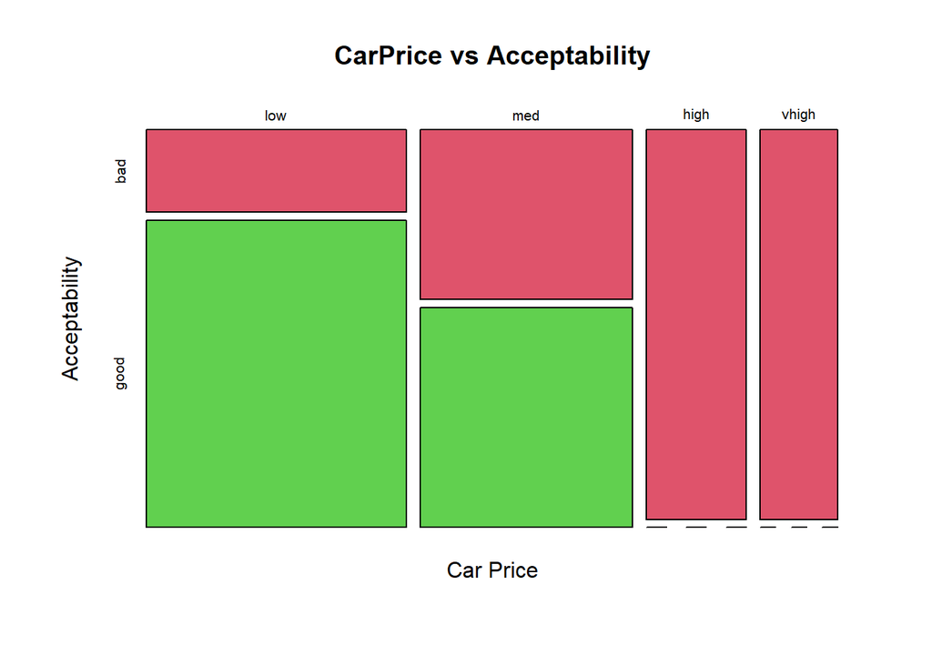

```r
#creating a mosaicplot of the price of the car against acceptability, xlab and ylab are used for x-axis and y-axis labels
#col specifies the colors which are red and green
mosaicplot(PriceTable,main="CarPrice vs Acceptability", xlab = "Car Price",ylab="Acceptability", col=c(2,3))
```

```r
#chisquare of price and acceptability
PriceChi = chisq.test(PriceTable,correct = F)
cat("P value of the relationship between Price and Acceptability is:",PriceChi$p.value)
```

```
## P value of the relationship between Price and Acceptability is: 4.758916e-23
```

Price vs Acceptability: the mosaic plot above shows that highly or very highly priced car have bad acceptabilities whereas low priced cars mostly have good acceptabilities. In addition the P-value corresponding to it is significant. It can therefore be inferred that the higher the price of the car is the less likely it is to be accepted hence a signficant relationship between Price and Acceptability can be deduced.

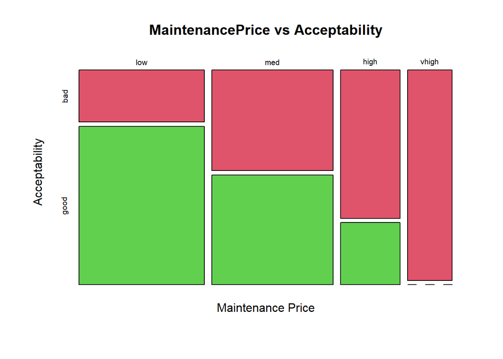

```r
#creating a mosaicplot of the maintenance price of the car against acceptability, xlab and ylab are used for x-axis and y-axis labels
#col specifies the colors which are red and green
mosaicplot(MaintenancePriceTable,main="MaintenancePrice vs Acceptability", xlab = "Maintenance Price",ylab="Acceptability", col=c(2,3))
```

```r
#chisquare of mainenance price and acceptability
MaintenanceChi = chisq.test(MaintenancePriceTable,correct = F)
cat("P value of the relationship between MaintenancePrice and Acceptability is:",MaintenanceChi$p.value)
```

```
## P value of the relationship between MaintenancePrice and Acceptability is: 7.101377e-14
```

MaintenancePrice vs Acceptability: the mosaic plot above shows that the majority of highly and very highly priced car maintenances have bad acceptabilities whereas low priced car maintenances mostly have good acceptabilities. In addition to that, the corresponding P-value is small enough and significant. It can therefore be inferred that the higher the price of the maintenance of the car is the less likely it is to be accepted hence a relationship between MaintenancePrice and Acceptability can be deduced.

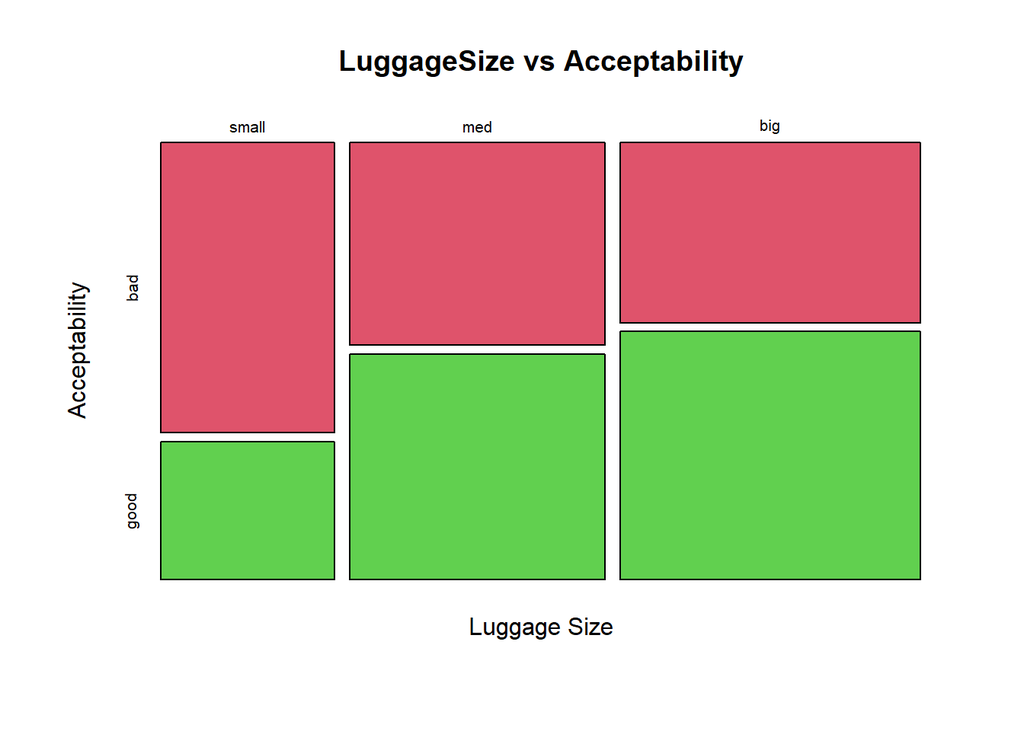

```r
#creating a mosaicplot of the luggage size of the car against acceptability, xlab and ylab are used for x-axis and y-axis labels
#col specifies the colors which are red and green
mosaicplot(LuggageTable,main="LuggageSize vs Acceptability", xlab = "Luggage Size",ylab="Acceptability", col=c(2,3))
```

```r
#chisquare of LuggageSize and Acceptability
LuggageChi = chisq.test(LuggageTable,correct = F)
cat("P value of the relationship between LuggageSize and Acceptability is:",LuggageChi$p.value)
```

```
## P value of the relationship between LuggageSize and Acceptability is: 0.00455716
```

LuggageSize vs Acceptability: the mosaic plot above indicated that most cars with small luggage sizes are not accepted whereas the majority of medium and big sized luggages are accepted. In addition to that the corresponding P value is significant hence a relationship can be confirmed between LuggageSize and Acceptability.

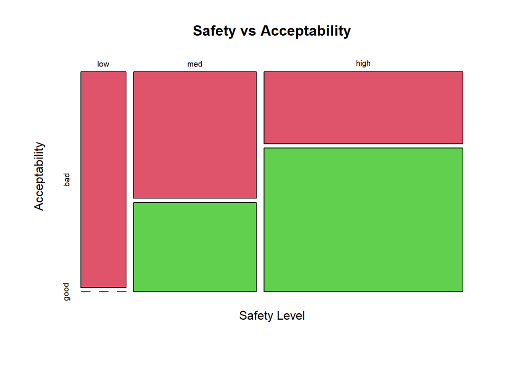

```r
#creating a mosaicplot of the safety of the car against acceptability, xlab and ylab are used for x-axis and y-axis labels
#col specifies the colors which are red and green
mosaicplot(SafetyTable,main="Safety vs Acceptability", xlab = "Safety Level",ylab="Acceptability", col=c(2,3))
```

```r
#chisquare of safety and acceptability
SafetyChi = chisq.test(SafetyTable,correct = F)
cat("P value of the relationship between LuggageSize and Acceptability is:",SafetyChi$p.value)
```

```
## P value of the relationship between LuggageSize and Acceptability is: 1.223847e-11
```

Safety vs Acceptability: the mosaic plot above shows that all low safety cars have bad acceptability and the majority of high safety cars have good acceptabilities. In addition to that, the corresponding P-values is small and significant hence a significant relationship can be inferred between Safety and Acceptability.

## 1.4 Encoding the Qualitative Predictors

The qualitative predictors have an ordinal level of measurement hence why we encoded the strings indicating the different categories with numbers to reflect their order which turns them into quantitative predictors.

```r
#as.numeric function is used to dummy encode the predictors after giving the correct levels using the factors function above
data$Price=as.numeric(data$Price)
data$MaintenancePrice = as.numeric(data$MaintenancePrice)
data$LuggageSize = as.numeric(data$LuggageSize)
data$Safety = as.numeric(data$Safety)
data$Acceptability = as.numeric(data$Acceptability)
#changing 1s into 0s and 2s into 1s since R usually starts encoding with 1 but we would like to have 0-1 for response encoding
data$Acceptability[data$Acceptability==1]=0
data$Acceptability[data$Acceptability==2]=1
#returning the columns as well as their types
str(data)
```

```
## 'data.frame':    260 obs. of  7 variables:
##  $ Price           : num  3 3 1 3 3 2 1 3 3 2 ...
##  $ MaintenancePrice: num  2 2 2 2 2 4 4 1 3 2 ...
##  $ NbDoors         : num  2 4 5 4 4 4 3 4 5 3 ...
##  $ PersonsCapacity : num  4 4 4 6 6 6 4 6 6 6 ...
##  $ LuggageSize     : num  2 3 1 3 1 1 2 1 2 2 ...
##  $ Safety          : num  3 3 2 3 3 3 3 3 3 2 ...
##  $ Acceptability   : num  0 0 0 0 0 0 0 0 0 0 ...
```

## 1.5 Quantitative Predictors

NbDoors and PersonsCapacity are quantitative predictors hence a boxplot would be suitable to summarize and display the relationship between them and Acceptability. We created boxplots using the **`plot()`** function colored in red for bad acceptability and green for good acceptabilities

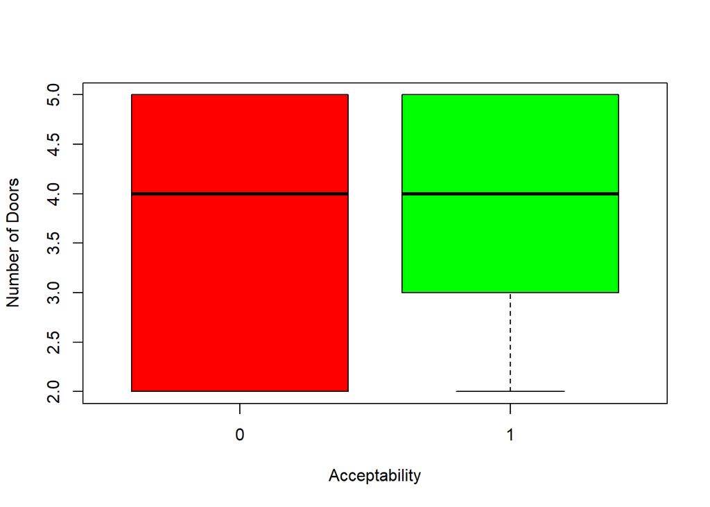

```r
#Number of Doors vs Acceptability Boxplot
boxplot(data$NbDoors~data$Acceptability, col=c('red','green'), varwidth=T, xlab="Acceptability", ylab="Number of Doors")
```

NbDoors vs Acceptability: The boxplot above shows that the observations of bad acceptability are spread all over the range of values for NbDoors. Moreover, there exists an overlap of the Interquartile range (IQR) of good and bad acceptability with respect to NbDoors however the variability of the good acceptability observations is smaller than that of bad. Also both medians are equal to 4. All of this indicates that the Number of Doors does not seem to be a useful factor to discriminate well enough between good and bad acceptability.

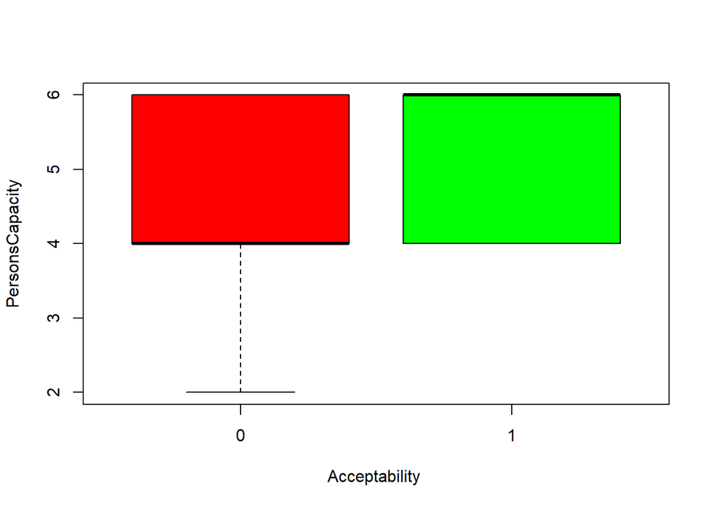

```r
#Persons' Capacity vs Acceptability Boxplot
boxplot(data$PersonsCapacity~data$Acceptability, col=c('red','green'), varwidth=T, xlab="Acceptability ", ylab="PersonsCapacity")
```

PersonsCapacity vs Acceptability: the box plot above shows that all good acceptability observations have 4 to 6 Persons’ Capacities. In addition to that the median of good acceptability cars is 6 whereas the median of bad acceptability cars is 4 which allows this predictor to discriminate to an extent between good and bad predictors.

## 1.6 Feature Selection

Following the analysis of the mosaic plots of Price and MaintenancePrice, a correlation was suspected between them since both of them had mostly bad acceptabilities for their high categories and good acceptability for their low and medium categories. To prove that, we conducted a chi square test which is used to check for a relationship between two categorical variables and we displayed the P value which indicated a significant correlation between these two predictors. Based on these results, we decided to remove one of these predictors (Price) and keep MaintenancePrice.

```r
#table of car price vs maintenance price
InteractionTable = table(data$Price,data$MaintenancePrice)
#chisquare of car price and maintenance price
chi = chisq.test(InteractionTable,correct = F)
cat("P value of the relationship between price and maintenance price is:",chi$p.value)
```

```
## P value of the relationship between price and maintenance price is: 0.007538537
```

Following the analysis of the boxplot displaying the relationship between NbDoors and Acceptability, it can be concluded that this predictor does not have a good discriminatory power and therefore can be disregarded when running the machine learning models.

This leaves us with 4 predictors: MaintenancePrice, LuggageSize, PersonsCapacity and Safety.

# 2 Validation Set Approach

First, we set a random seed which is a number needed by the random number generator to work and allows us to reproduce the exact same random numbers. Then, we split our data into a training set and a test set for us to check how much the models that will be trained are able to perform on data that they never saw before. The training set consists of 75% of the data that were sampled without replacement and with equal probabilities of being picked.

```r
#setting seed to 100
set.seed(100)
#taking 75% of the number of rows as a sample size
sample_size <- floor(0.75 * nrow(data))
# returning a vector of randomly picked indices of size equal to sample size
train_index <- sample(seq_len(nrow(data)), size = sample_size)
#assigning the rows in the dataset which have indices in the train_index to be in the training set
train <- data[train_index, ]
#assigning the remaining rows to be in the test set
test <- data[-train_index, ]
```

# 3 Logistic Regression

## 3.1 Training & Testing

We create a Logistic Regression Model using the training data subset that we have already created This logistic regression model takes into consideration the 4 predictors we selected. Following that, we used the trained model to predict the responses of the test set.

```r
#logistic model with acceptability as response and maintenanceprice, luggagesize, personscapacity, and safety as predictors
#using the training set to train the model
glm.fit=glm(Acceptability~MaintenancePrice+LuggageSize+PersonsCapacity+Safety,data=train,family=binomial)
#pringint summary of our model
summary(glm.fit)
```

```
##
## Call:
## glm(formula = Acceptability ~ MaintenancePrice + LuggageSize +
##     PersonsCapacity + Safety, family = binomial, data = train)
##
## Deviance Residuals:
##      Min        1Q    Median        3Q       Max
## -2.77593  -0.53637  -0.06756   0.68292   1.83176
##
## Coefficients:
##                  Estimate Std. Error z value Pr(>|z|)
## (Intercept)       -6.1459     1.5656  -3.926 8.65e-05 ***
## MaintenancePrice  -1.4824     0.2661  -5.570 2.54e-08 ***
## LuggageSize        1.0871     0.2883   3.771 0.000162 ***
## PersonsCapacity    0.4675     0.1663   2.810 0.004949 **
## Safety             1.7979     0.3807   4.723 2.32e-06 ***
## ---
## Signif. codes:  0 '***' 0.001 '**' 0.01 '*' 0.05 '.' 0.1 ' ' 1
##
## (Dispersion parameter for binomial family taken to be 1)
##
##     Null deviance: 270.20  on 194  degrees of freedom
## Residual deviance: 159.56  on 190  degrees of freedom
## AIC: 169.56
##
## Number of Fisher Scoring iterations: 5
```

```r
#testing the model by predicting the response on the test dataset (returning a probability value) and saving it
glm.probs <- predict(glm.fit,newdata= test,type = "response")
# if the probability is greater than 0.5 then its good (1) else it is bad (0)
glm.pred <- ifelse(glm.probs > 0.5,1,0)
```

The summary displays the P-values of each of the 4 predictors which indicates high significance for all of them. It also displays the intercept and the coefficients.

## 3.2 Results & Analysis

```r
#table of the predictions of model on test set vs the real values being predicted
logConfusionMatrix= table(glm.pred, test$Acceptability)
#calculating test error rate by taking the mean function of false predictions
cat("Logistic Regression Model Test Error Rate:",mean(glm.pred != test$Acceptability),"\n")
```

```
## Logistic Regression Model Test Error Rate: 0.1692308
```

```r
#displaying confusion matrix
cat("Logistic Regression Model Confusion Matrix:")
```

```
## Logistic Regression Model Confusion Matrix:
```

```r
logConfusionMatrix
```

```
##
## glm.pred  0  1
##        0 25  6
##        1  5 29
```

```r
#calculating accuracy by summing the correct predictions and diving it on the total number of predictions
cat("\nFraction of correct predictions (Accuracy):",sum(diag(logConfusionMatrix))/sum(logConfusionMatrix)*100,"%\n")
```

```
##
## Fraction of correct predictions (Accuracy): 83.07692 %
```

```r
#calculating precision by dividing the correct positive predictions over the sum of total positive predictions (TP + FP)
logPrec = logConfusionMatrix[4]/sum(glm.pred == 1)
#calculating precision by dividing the correct positive predictions over the sum of total real positive values (TP + FN)
logrecall =  (logConfusionMatrix[4]/(logConfusionMatrix[4]+logConfusionMatrix[3]))
#printing the values out
cat("Precision:", logPrec * 100, "%\n")
```

```
## Precision: 85.29412 %
```

```r
cat("Recall: ", logrecall*100,"%\n")
```

```
## Recall:  82.85714 %
```

```r
#calculating the f1s score
f1Log = (2*logrecall*logPrec)/(logPrec+logrecall)
cat("F1Score: ", f1Log,"\n")
```

```
## F1Score:  0.8405797
```

The metrics evaluating our logistic regression model reflect a good performance as it has a low MSE (0.1692308) which means that the fraction of the false predictions is low. In addition, the accuracy showed that the model correctly classified 83.07692% of the observations. The precision shows that out of all the positively predicted observations (good acceptability) 85.29412% are actually positive. The recall indicates that out of all the actual positive observations, 82.85714% were positively predicted.

Furthermore, the confusion matrix displays the number of false positives, meaning our model predicted the car to have a good acceptability when it actually has a bad one. We can also see the number of false negatives, meaning our model predicted the car to have a bad acceptability when it actually has a good one.

```r
#printing out false positives
cat("False Positives:", logConfusionMatrix[2] ,"out of",sum(glm.pred == 1),"good predictions\n")
```

```
## False Positives: 5 out of 34 good predictions
```

```r
#printing out false negatives
cat("False Negatives:", logConfusionMatrix[3] ,"out of",sum(glm.pred == 0),"bad predictions")
```

```
## False Negatives: 6 out of 31 bad predictions
```

ROC curves illustrate the diagnostic ability of a binary classifier when its discrimination threshold is varied. The below ROC curve corresponds to our Logistic Regression Model. The area under the curve corresponds to the AUC score which is equal to 0.9171429 meaning that the model has a high ability to distinguish between classes.

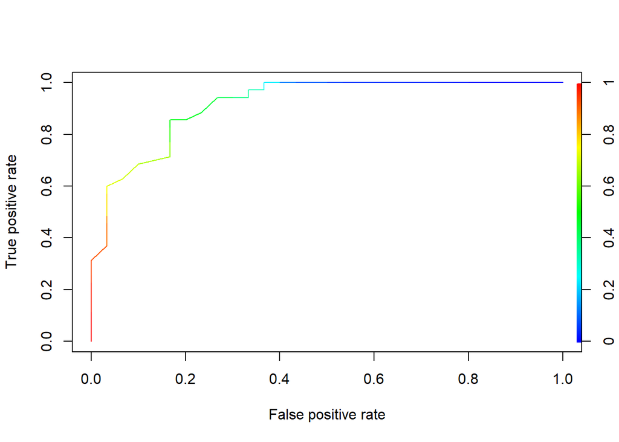

```r
library(ROCR)
#creating a ROC curve using the ROCR library
newlog = prediction(glm.probs,test$Acceptability)
#calculating the tpr and fpr for different thresholds and saving them
roccurve=performance(newlog,"tpr","fpr")
#plotting the ROC curve
plot(roccurve,colorize=T)
```

```r
#performance instance used to store area under the curve
aucLog = performance(newlog,"auc")
#calculating the area under the curve
LogRegAUC = as.numeric(aucLog@y.values)
LogRegAUC
```

```
## [1] 0.9171429
```

# 4 LDA

## 4.1 Training & Testing

We create a Linear Discriminant Analysis (LDA) Model using the training data subset that we have already created. Similarly, this LDA model takes into consideration the 4 predictors we selected. Following that, we used the trained model to predict the responses of the test set.

```r
library(MASS)
#training LDA model on training data having acceptability as response and the same 4 predictors as the logestic regression model
lda.fit=lda(Acceptability~MaintenancePrice+LuggageSize+PersonsCapacity+Safety,data=train)
lda.fit
```

```
## Call:
## lda(Acceptability ~ MaintenancePrice + LuggageSize + PersonsCapacity +
##     Safety, data = train)
##
## Prior probabilities of groups:
##         0         1
## 0.5128205 0.4871795
##
## Group means:
##   MaintenancePrice LuggageSize PersonsCapacity   Safety
## 0         2.600000    2.060000        4.180000 2.150000
## 1         1.589474    2.284211        5.052632 2.736842
##
## Coefficients of linear discriminants:
##                         LD1
## MaintenancePrice -0.8367395
## LuggageSize       0.5945426
## PersonsCapacity   0.2684943
## Safety            0.9078342
```

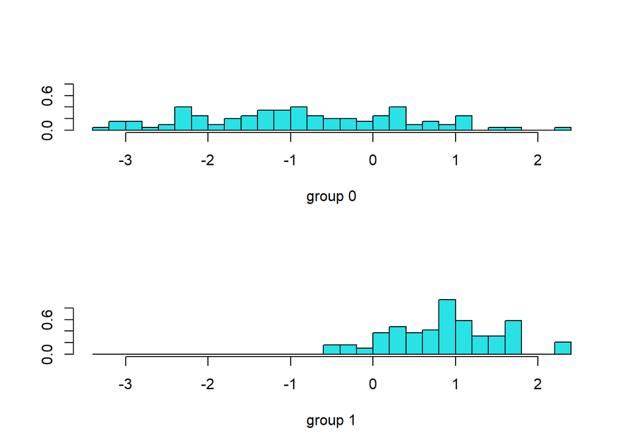

```r
#plotting the model
plot(lda.fit)
```

```r
#testing the model by predicting the responses of the test dataset and saving them in lda.pred
lda.pred=predict(lda.fit, test)
#taking the results of the prediction
lda.class=lda.pred$class
```

## 4.2 Results & Analysis

```r
#MSE, CONFUSION MATRIC AND DIFFERENT METRICS
#confusion matrix of predicted responses vs real responses
LDAConfusionMatrix= table(lda.class, test$Acceptability)
#calculating error rate by taking the mean function of the number of incorrect predictions
cat("LDA Test Error Rate:",mean(lda.class != test$Acceptability),"\n")
```

```
## LDA Test Error Rate: 0.1692308
```

```r
cat("\nLDA Confusion Matrix:")
```

```
##
## LDA Confusion Matrix:
```

```r
LDAConfusionMatrix
```

```
##
## lda.class  0  1
##         0 24  5
##         1  6 30
```

```r
cat("\nFraction of correct predictions (Accuracy):",sum(diag(LDAConfusionMatrix))/sum(LDAConfusionMatrix)*100,"%\n")
```

```
##
## Fraction of correct predictions (Accuracy): 83.07692 %
```

```r
#precision, recall,f1score same as logistic regression
LDAPrec = LDAConfusionMatrix[4]/sum(lda.class == 1)
LDArecall =  (LDAConfusionMatrix[4]/(LDAConfusionMatrix[4]+LDAConfusionMatrix[3]))

cat("Precision:", LDAPrec * 100, "%\n")
```

```
## Precision: 83.33333 %
```

```r
cat("Recall: ", LDArecall*100,"%\n")
```

```
## Recall:  85.71429 %
```

```r
f1LDA = (2*LDArecall*LDAPrec)/(LDAPrec+LDArecall)
cat("F1Score: ", f1LDA,"\n")
```

```
## F1Score:  0.8450704
```

```r
#False positives and negatives calculated same as logistic regression
cat("False Positives:", LDAConfusionMatrix[2] ,"out of",sum(lda.class == 1),"good predictions\n")
```

```
## False Positives: 6 out of 36 good predictions
```

```r
cat("False Negatives:", LDAConfusionMatrix[3] ,"out of",sum(lda.class == 0),"bad predictions")
```

```
## False Negatives: 5 out of 29 bad predictions
```

The below ROC curve corresponds to our LDA Model. The area under the curve corresponds to the AUC score which is equal to 0.9161905 meaning that the model has a high ability to distinguish between classes.

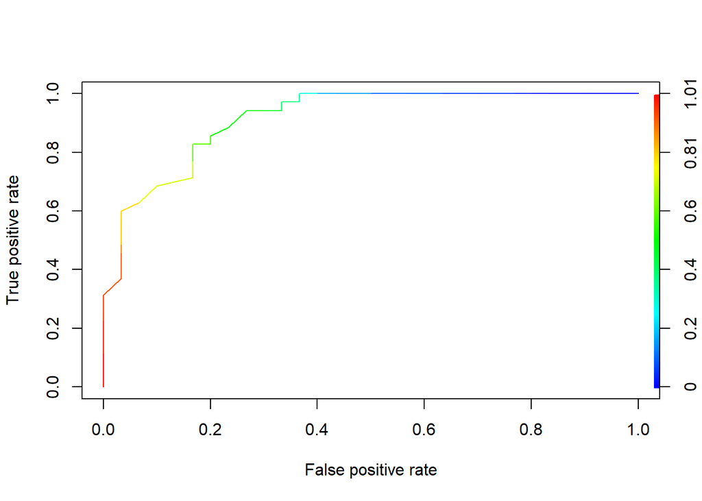

```r
#ROC CURVE AND AUC
#Calculated in the same method as logistic regression above
newlogLDA=prediction(lda.pred$posterior[,2], test$Acceptability)
LDAROC=performance(newlogLDA,"tpr","fpr")
plot(LDAROC,colorize=T)
```

```r
aucLDA.tmp = performance(newlogLDA,"auc")
aucLDA = as.numeric(aucLDA.tmp@y.values)
print(aucLDA)
```

```
## [1] 0.9161905
```

# 5 QDA

## 5.1 Training & Testing

We create a QDA Model using the training data subset that we have already created. Similarly, this LDA model takes into consideration the 4 predictors we selected. Following that, we used the trained model to predict the responses of the test set.

```r
#training qda model on training data by taking acceptability as response and same 4 predictors as previous models
qda.fit=qda(Acceptability~MaintenancePrice+LuggageSize+PersonsCapacity+Safety,data=train)
qda.fit
```

```
## Call:
## qda(Acceptability ~ MaintenancePrice + LuggageSize + PersonsCapacity +
##     Safety, data = train)
##
## Prior probabilities of groups:
##         0         1
## 0.5128205 0.4871795
##
## Group means:
##   MaintenancePrice LuggageSize PersonsCapacity   Safety
## 0         2.600000    2.060000        4.180000 2.150000
## 1         1.589474    2.284211        5.052632 2.736842
```

```r
#testing qda model by predicting response of test dataset
qda.pred = predict(qda.fit,test)
#taking the results and saving them
qda.class=qda.pred$class
```

## 5.2 Results & Analysis

```r
#MSE, CONFUSION MATRIC AND DIFFERENT METRICS
#creating confusion matrix of the predicted responses vs their real values
QDAConfusionMatrix= table(qda.class, test$Acceptability)
#calculating test error rate in the same way as previous models
cat("QDA Test Error Rate:",mean(qda.class != test$Acceptability),"\n")
```

```
## QDA Test Error Rate: 0.1384615
```

```r
cat("QDA Confusion Matrix:")
```

```
## QDA Confusion Matrix:
```

```r
QDAConfusionMatrix
```

```
##
## qda.class  0  1
##         0 24  3
##         1  6 32
```

```r
#calculating Accuracy
cat("Fraction of correct predictions (Accuracy):",sum(diag(QDAConfusionMatrix))/sum(QDAConfusionMatrix)*100,"%\n")
```

```
## Fraction of correct predictions (Accuracy): 86.15385 %
```

```r
QDAPrec = QDAConfusionMatrix[4]/sum(qda.class == 1)
QDArecall =  (QDAConfusionMatrix[4]/(QDAConfusionMatrix[4]+QDAConfusionMatrix[3]))
#calculating Precision and Recall
cat("Precision:", QDAPrec * 100, "%\n")
```

```
## Precision: 84.21053 %
```

```r
cat("Recall: ", QDArecall*100,"%\n")
```

```
## Recall:  91.42857 %
```

```r
#calculating qdas f1score
f1QDA = (2*QDArecall*QDAPrec)/(QDAPrec+QDArecall)
cat("F1Score: ", f1QDA,"\n")
```

```
## F1Score:  0.8767123
```

```r
#calculating the number of false positives and false negatives
cat("False Positives:", QDAConfusionMatrix[2] ,"out of",sum(qda.class == 1),"good predictions\n")
```

```
## False Positives: 6 out of 38 good predictions
```

```r
cat("False Negatives:", QDAConfusionMatrix[3] ,"out of",sum(qda.class == 0),"bad predictions")
```

```
## False Negatives: 3 out of 27 bad predictions
```

The below ROC curve corresponds to our QDA Model. The area under the curve corresponds to the AUC score which is equal to 0.9190476 meaning that the model has a high ability to distinguish between classes.

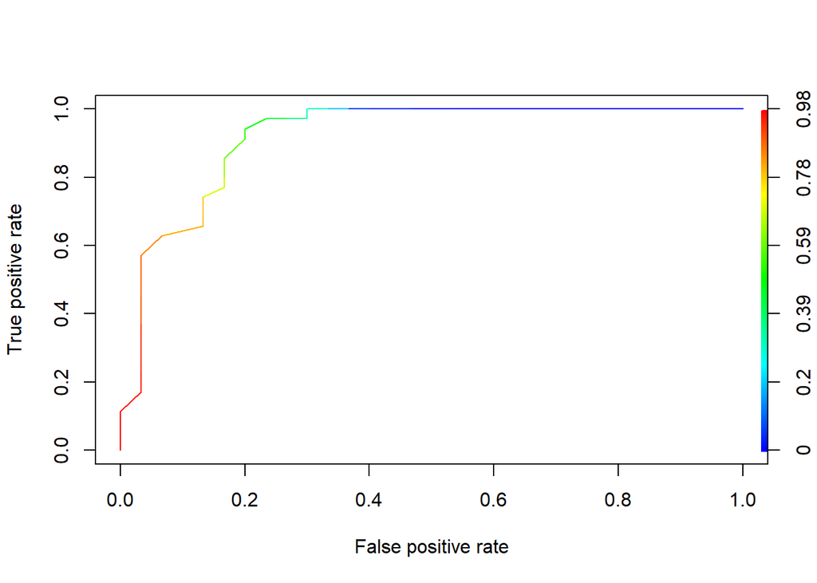

```r
#Computing the ROC and AUC of the qda model
newlogQDA=prediction(qda.pred$posterior[,2], test$Acceptability)
#testing the performance of difference thresholds
QDAROC=performance(newlogQDA,"tpr","fpr")
#plotting the qda ROC curve
plot(QDAROC,colorize=T)
```

```r
auc.tmpqda<- performance(newlogQDA,"auc")
aucqda<- as.numeric(auc.tmpqda@y.values)
#printing the AUC value
print(aucqda)
```

```
## [1] 0.9190476
```

# 6 Models Comparison

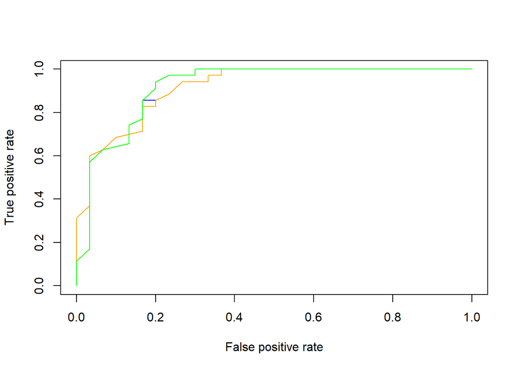

```r
#plotting the ROC curves of the different produced models in the same plot by adding them using add attribute
plot(roccurve,col="blue")
plot(LDAROC,add = TRUE, col="orange")
plot(QDAROC,add=TRUE,col="green")
```

When plotting the three ROC curves of the 3 models we ran together in one graph, we can clearly illustrate that QDA (green) performs slightly better than the Logistic Regression (blue) and LDA (orange) who perform almost identically. This is also shown through the test MSE which is the lowest for QDA. It should be noted that LDA and logistic regression had the exact same MSE.

# 7 KNN

```r
library(class)
#setting a new seed for the KNN
set.seed(12234)
#taking predictors from the training dataset and binding them to train.X vector
train.X = cbind(train$MaintenancePrice, train$PersonsCapacity, train$LuggageSize,train$Safety)
#taking predictors from test dataset and binding them to test.X vector
test.X = cbind(test$MaintenancePrice, test$PersonsCapacity, test$LuggageSize,test$Safety)
train.Acceptability = train$Acceptability
#vector containing different values of k that will be used
kvalues = c(1,3,9,15,20,25)
#empty list to hold predictions produced later on
knnpredictions = list()
#looping over k values
for (k in kvalues){
#performing knn model
knn.pred = knn(train.X,test.X,train.Acceptability,k=k)
#adding results to the empty list
knnpredictions[[length(knnpredictions)+1]] <- list(knn.pred)
}
#counter to help printing the value of k
counter=1
#empty vector to store the test errors of each model
knnerrors = c()
for ( predictions in knnpredictions){
  #changing the list into a vector called knn.pred
  knn.pred = unlist(predictions)
  #producing a table of the predicted responses vs the true responses
  knntable = table(knn.pred,test$Acceptability)
  cat("for k =",kvalues[counter],":\n")
  #calculating the accuracy and test error for each model of a specific k value
  cat("Accuracy:",sum(diag(knntable))/sum(knntable)*100,"%\n")
  cat("Test Error:",(1-sum(diag(knntable))/sum(knntable)),"\n")
  #saving the knnerrors
  knnerrors <- c(knnerrors,(1-sum(diag(knntable))/sum(knntable))*100)
  #calculating the number of false positives and false negatives
  cat("False Positives:", knntable[2] ,"out of",sum(knn.pred ==1),"\n")
  cat("False Negatives:", knntable[3] ,"out of",sum(knn.pred ==0),"\n\n")
  counter = counter+1
}
```

```
## for k = 1 :
## Accuracy: 81.53846 %
## Test Error: 0.1846154
## False Positives: 9 out of 41
## False Negatives: 3 out of 24
##
## for k = 3 :
## Accuracy: 78.46154 %
## Test Error: 0.2153846
## False Positives: 10 out of 41
## False Negatives: 4 out of 24
##
## for k = 9 :
## Accuracy: 83.07692 %
## Test Error: 0.1692308
## False Positives: 10 out of 44
## False Negatives: 1 out of 21
##
## for k = 15 :
## Accuracy: 80 %
## Test Error: 0.2
## False Positives: 12 out of 46
## False Negatives: 1 out of 19
##
## for k = 20 :
## Accuracy: 78.46154 %
## Test Error: 0.2153846
## False Positives: 13 out of 47
## False Negatives: 1 out of 18
##
## for k = 25 :
## Accuracy: 75.38462 %
## Test Error: 0.2461538
## False Positives: 15 out of 49
## False Negatives: 1 out of 16
```

We can see that for k = 9 we obtain the least amount of errors and the highest accuracy between the k values tested on. The model works really well when classifying cars with good acceptability when they are indeed good since it had only 1 false negative bad classified cars are correct. The model also worked well when classifying the cars with bad acceptability since it only classified 10 bad cars as good out of 44 good cars (false positives) and the rest are classified correctly.

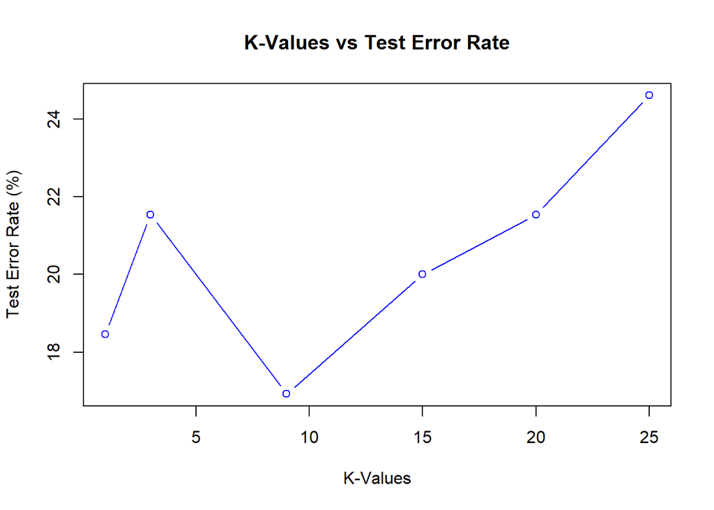

```r
#ploting test error vs value of k
plot(kvalues,knnerrors,type = "b",col="blue",main="K-Values vs Test Error Rate",xlab="K-Values",ylab="Test Error Rate (%)")
```

# 8 5-Fold Cross Validation

In the following step, we applied a 5-Fold Cross Validation on the Logistic Regression Model using the **`cv.glm()`** function and we displayed the cross-validation estimate of prediction error

```r
library(boot)
#setting seed
set.seed(20)
glm.fitLogReg=glm(Acceptability~MaintenancePrice+LuggageSize+PersonsCapacity+Safety,data=data,family=binomial)
cv.error=cv.glm(data,glm.fitLogReg,K=5)$delta[1]
cv.error
```

```
## [1] 0.1315544
```

## 8.1 Comparison with Validation Set Approach

The estimate of prediction error (0.1315544) obtained from the 5-fold cross validation is much better than that of the validation set approach (0.169) which can be explained by the fact that the dataset is relatively small and the 5-fold cross validation approach uses all of the data using k=5 different models. The model may be yielding better results in the 5-fold cross validation approach because it is being trained on more data than in the validation set approach which usually overestimates the test error rate

# 9 Bootstrap

We used the bootstrap method to assess the variability of the coefficient estimates and predictions from the logistic regression model.

```r
#creating the boostrap function
bootstrap.fn=function(data,index){
return(coef(glm(Acceptability~MaintenancePrice+LuggageSize+PersonsCapacity+Safety,data=data,family=binomial,subset=index)))
}
#running the function on the current dataset
cat("Using the current dataset results:\n")
```

```
## Using the current dataset results:
```

```r
bootstrap.fn(data,1:nrow(data))
```

```
##      (Intercept) MaintenancePrice      LuggageSize  PersonsCapacity
##       -6.0252846       -1.5875062        1.0936197        0.3763884
##           Safety
##        2.0238159
```

```r
#running the function on equally sized dataset with random sampling from our original observations
cat("Randomly sampling from the pre-existing observations with replacement results:\n")
```

```
## Randomly sampling from the pre-existing observations with replacement results:
```

```r
set.seed(1)
bootstrap.fn(data,sample(nrow(data),nrow(data),replace=T))
```

```
##      (Intercept) MaintenancePrice      LuggageSize  PersonsCapacity
##       -4.5587023       -1.6778370        0.9334044        0.3104447
##           Safety
##        1.7906002
```

```r
#computing the standard errors of 10 bootstrap estimates
boot(data ,bootstrap.fn ,10)
```

```
##
## ORDINARY NONPARAMETRIC BOOTSTRAP
##
##
## Call:
## boot(data = data, statistic = bootstrap.fn, R = 10)
##
##
## Bootstrap Statistics :
##       original      bias    std. error
## t1* -6.0252846 -0.54487132   1.1547314
## t2* -1.5875062 -0.07662605   0.3128844
## t3*  1.0936197  0.14449547   0.2285338
## t4*  0.3763884  0.01081543   0.1470900
## t5*  2.0238159  0.15962946   0.3354310
```

```r
cat("The bootstrap estimate for the standard error of the coefficient of:
- MaintenancePrice is 0.3128844
- LuggageSize is 0.2285338
- PersonsCapacity 0.1470900
- Safety is 0.3354310\n")
```

```
## The bootstrap estimate for the standard error of the coefficient of:
## - MaintenancePrice is 0.3128844
## - LuggageSize is 0.2285338
## - PersonsCapacity 0.1470900
## - Safety is 0.3354310
```

# 10 Conclusion